## Introduction

Purpose: to use life tables in hopes of describing or explaining the observed skew in striped bass sex ratio. Though with some variation, the fraction of females has diminished over time.

## Data Overview

Table below shows years in which we did not sample and in years of sampling, which gears we deployed (`FT` = fyke traps, `GN` = gill nets). Note: in 2011, gill nets were deployed one day (Apr-19), catching 17 striped bass (38-56 cm FL).

NOTE: Fish caught after 2009 have not yet been aged.

| Year | Method | Year | Method | Year | Method | Year | Method | Year | Method |
| --- | --- | --- | --- | --- | --- | --- | --- | --- | --- |
| 1969 | FT & GN | 1979 | FT & GN | 1989 | FT & GN | 1999 | no tagging | 2009 | FT & GN |
| 1970 | FT & GN | 1980 | FT & GN | 1990 | FT & GN | 2000 | FT & GN | 2010 | FT |
| 1971 | FT & GN | 1981 | FT & GN | 1991 | FT & GN | 2001 | no tagging | 2011 | FT & GN |
| 1972 | FT & GN | 1982 | FT & GN | 1992 | FT & GN | 2002 | GN | 2012 | FT |
| 1973 | FT & GN | 1983 | FT & GN | 1993 | FT & GN | 2003 | FT & GN | 2013 | FT |
| 1974 | FT & GN | 1984 | FT & GN | 1994 | FT & GN | 2004 | FT & GN | 2014 | no tagging |
| 1975 | FT & GN | 1985 | FT & GN | 1995 | no tagging | 2005 | FT & GN | 2015 | FT |
| 1976 | FT & GN | 1986 | FT & GN | 1996 | FT & GN | 2006 | no tagging | 2016 | FT |
| 1977 | GN | 1987 | FT & GN | 1997 | no tagging | 2007 | FT | 2017 | FT |
| 1978 | GN | 1988 | FT & GN | 1998 | GN | 2008 | FT & GN |  |  |

Graphic below shows by fyke trap sampling locations annual fraction of females (as `females / (males + females)`). Table below defines numeric locations.

| Code | Location |
| --- | --- |
| 05 | Ida’s Island (Sacramento River below Isleton) |
| 12 | Clarksburg |
| 13 | Fremont Weir |
| 14 | Colusa |
| 15 | Freeport |
| 16 | Knights Landing |

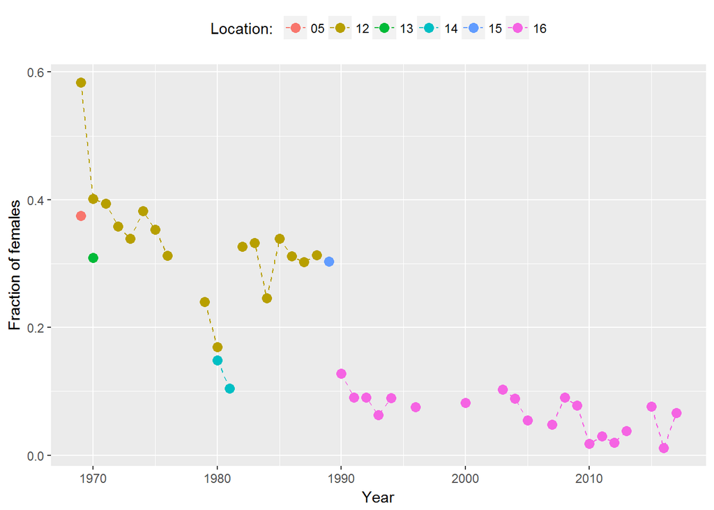

## Life Tables

We begin life tables by looking at the annual frequency (catch) of each age. For ease of display, we show the first 10 years along with ages 3-12.

```
##        Age
## RelYear    3    4    5    6    7    8    9   10   11   12
##    1969 1334 3770 3635 2962 1379  928  701  527  344  145
##    1970 1354 2018 1512  827  627  282  162  107   70   64
##    1971 1678 3651 1783  751  411  345  166  126   73   73
##    1972 4115 4763 4950 1557  884  517  438  131  145   93
##    1973 1938 5687 2796 2417  744  452  360  247  157   62
##    1974 2988 4153 3156 1158  868  305  199  163   99   48
##    1975 1844 3292 1215 1063  316  245  102   85   56   36
##    1976 2130 3391 2530  851  597  220  151   84   39   31
##    1977 1107 2091  803  456  163   89   43   26   25   12
##    1978 1345 1743  647  260  113   29   26   13    4    2
```

A static life table uses frequency (catch) within a single year (e.g., see 1969 below).

```
##        Age
## RelYear    3    4    5    6    7    8    9   10   11   12
##    1969 1334 3770 3635 2962 1379  928  701  527  344  145
```

A cohort life table tracks a cohort through time. Below we start with age-3 fish in 1969, followed (9 years forward) to age-12. We use this “diagonal” frequency (catch) for cohort life tables.

```
##        Age
## RelYear 3    4    5    6    7   8   9   10 11 12
##    1969 1334
##    1970      2018
##    1971           1783
##    1972                1557
##    1973                     744
##    1974                         305
##    1975                             102
##    1976                                 84
##    1977                                    25
##    1978                                       2
```

### Static Life Table

Here we show (as an example) a static life table for 1969 fyke trap sampling. Top table is for males, bottom for females.

```
$`1969.FT.M`
    x  nx          lx           dx          qx    Lx    Tx   ex
1   4 380 1.000000000  0.484210526  0.48421053 288.0 596.0 1.57
2   5 196 0.515789474  0.226315789  0.43877551 153.0 308.0 1.57
3   6 110 0.289473684  0.197368421  0.68181818  72.5 155.0 1.41
4   7  35 0.092105263 -0.002631579 -0.02857143  35.5  82.5 2.36
5   8  36 0.094736842  0.047368421  0.50000000  27.0  47.0 1.31
6   9  18 0.047368421  0.039473684  0.83333333  10.5  20.0 1.11
7  10   3 0.007894737  0.000000000  0.00000000   3.0   9.5 3.17
8  11   3 0.007894737  0.002631579  0.33333333   2.5   6.5 2.17
9  12   2 0.005263158  0.002631579  0.50000000   1.5   4.0 2.00
10 13   1 0.002631579 -0.002631579 -1.00000000   1.5   2.5 2.50
11 14   2 0.005263158  0.005263158  1.00000000   1.0   1.0 0.50

$`1969.FT.F`
    x  nx          lx           dx          qx    Lx    Tx   ex
1   4 284 1.000000000 -0.257042254 -0.25704225 320.5 990.0 3.49
2   5 357 1.257042254  0.450704225  0.35854342 293.0 669.5 1.88
3   6 229 0.806338028  0.485915493  0.60262009 160.0 376.5 1.64
4   7  91 0.320422535  0.161971831  0.50549451  68.0 216.5 2.38
5   8  45 0.158450704  0.007042254  0.04444444  44.0 148.5 3.30
6   9  43 0.151408451  0.042253521  0.27906977  37.0 104.5 2.43
7  10  31 0.109154930  0.010563380  0.09677419  29.5  67.5 2.18
8  11  28 0.098591549  0.049295775  0.50000000  21.0  38.0 1.36
9  12  14 0.049295775  0.031690141  0.64285714   9.5  17.0 1.21
10 13   5 0.017605634  0.003521127  0.20000000   4.5   7.5 1.50
11 14   4 0.014084507  0.010563380  0.75000000   2.5   3.0 0.75
12 15   1 0.003521127  0.003521127  1.00000000   0.5   0.5 0.50
```

### Cohort Life Table

Here we show (as an example) a cohort life table for 1969 fyke trap sampling. Top table is for males, bottom for females. As we did not deploy fyke traps in 1977 & 1978, no data are available for ages 12 & 13.

```
    x  nx          lx           dx          qx    Lx    Tx   ex
1   4 380 1.000000000  0.615789474  0.61578947 263.0 920.5 2.42
2   5 146 0.384210526  0.139473684  0.36301370 119.5 657.5 4.50
3   6  93 0.244736842 -0.263157895 -1.07526882 143.0 538.0 5.78
4   7 193 0.507894737  0.005263158  0.01036269 192.0 395.0 2.05
5   8 191 0.502631579  0.347368421  0.69109948 125.0 203.0 1.06
6   9  59 0.155263158  0.068421053  0.44067797  46.0  78.0 1.32
7  10  33 0.086842105  0.031578947  0.36363636  27.0  32.0 0.97
8  11  21 0.055263158           NA          NA    NA    NA   NA
9  12  NA          NA           NA          NA    NA    NA   NA
10 13  NA          NA           NA          NA    NA    NA   NA
11 14   2 0.005263158  0.002631579  0.50000000   1.5   5.0 2.50
12 15   1 0.002631579 -0.002631579 -1.00000000   1.5   3.5 3.50
13 16   2 0.005263158  0.002631579  0.50000000   1.5   2.0 1.00
14 17   1 0.002631579  0.002631579  1.00000000   0.5   0.5 0.50
15 18   0 0.000000000  0.000000000         NaN   0.0   0.0  NaN
16 20   0 0.000000000  0.000000000         NaN   0.0   0.0  NaN
```

```
    x  nx          lx           dx         qx    Lx    Tx   ex
1   4 284 1.000000000  0.577464789  0.5774648 202.0 845.0 2.98
2   5 120 0.422535211 -0.052816901 -0.1250000 127.5 643.0 5.36
3   6 135 0.475352113 -0.394366197 -0.8296296 191.0 515.5 3.82
4   7 247 0.869718310  0.489436620  0.5627530 177.5 324.5 1.31
5   8 108 0.380281690  0.179577465  0.4722222  82.5 147.0 1.36
6   9  57 0.200704225  0.095070423  0.4736842  43.5  64.5 1.13
7  10  30 0.105633803  0.088028169  0.8333333  17.5  21.0 0.70
8  11   5 0.017605634           NA         NA    NA    NA   NA
9  12  NA          NA           NA         NA    NA    NA   NA
10 13  NA          NA           NA         NA    NA    NA   NA
11 14   3 0.010563380  0.010563380  1.0000000   1.5   3.5 1.17
12 15   0 0.000000000 -0.007042254       -Inf   1.0   2.0  Inf
13 16   2 0.007042254  0.007042254  1.0000000   1.0   1.0 0.50
14 17   0 0.000000000  0.000000000        NaN   0.0   0.0  NaN
15 18   0 0.000000000  0.000000000        NaN   0.0   0.0  NaN
16 19   0 0.000000000  0.000000000        NaN   0.0   0.0  NaN
17 20   0 0.000000000  0.000000000        NaN   0.0   0.0  NaN
```

end of report  
ran: 2017-06-28 15:52:24  
CDFW (2017)